# Data Speaks Happiness

Ghada Jerfel

9/16/2018

# Introduction

**Happiness** has long been the center of concern for humankind. It is one of the most broadly debated concept, yet the most intricate one. From Ancient Greece to Modern Day time, happiness has evolved as a as an existential purpose to include different aspects of modern day life such as a job promotion or purchasing a car. The search for happiness is inevitably an active task commonly shared by people from different geographies, ages, genders, races, etc. So, what defines happiness? Is happiness embodied in physical activity or emotional sentiments? Does youth define happiness from certain angles? Do women feel different from men and other genders when it comes to their happy moments? Do the “significant other” and children change one’s perspective of joy?

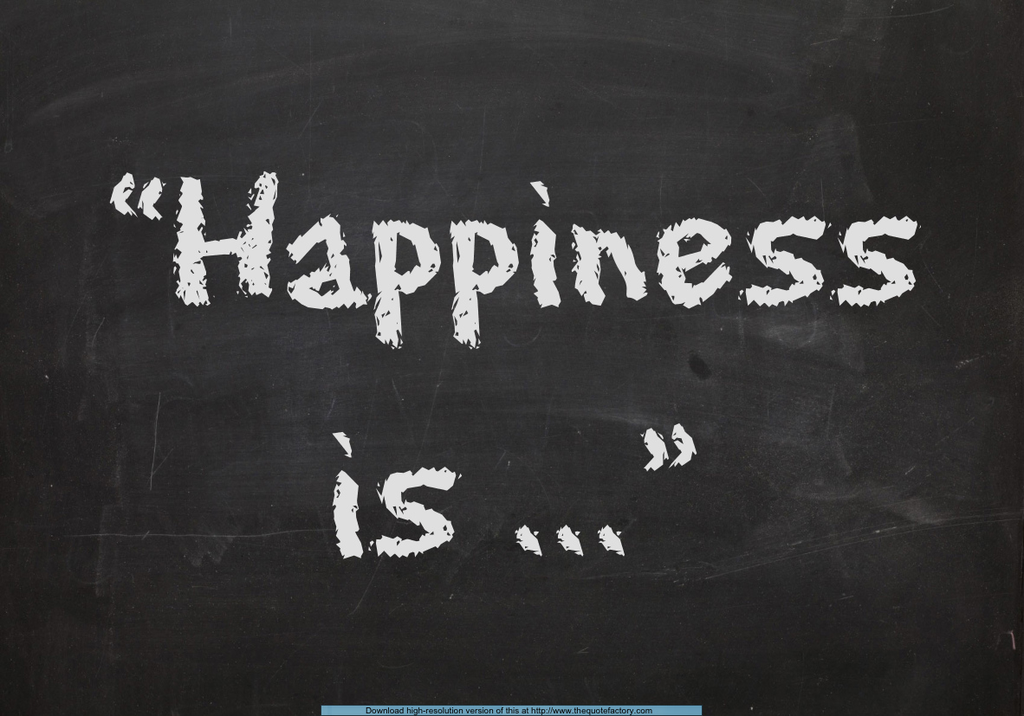

How relative is happiness?

In this context, I will explore what the HappyDB data provides us with: more than 100,000 crowd-sourced happy moments. The average age is 32 years old with the youngest interviewee being 17 years old and the oldest being 98 years old. Around 57% are men and 42% are women. Approximately 54% are single, 41% are married, roughly 4% are divorced and the remaining 1% are either separated or widowed. Below is a sample of the happy moments that the interviewed people described:

| original_hm |
| --- |
| I went on a successful date with someone I felt sympathy and connection with. |
| I was happy when my son got 90% marks in his examination |
| I went to the gym this morning and did yoga. |
| We had a serious talk with some friends of ours who have been flaky lately. They understood and we had a good evening hanging out. |
| I went with grandchildren to butterfly display at Crohn Conservatory\r\n |
| I meditated last night. |

This sample gives an insight about the different happy moments, which made the data analysts behind HappyDB create categories of happiness:

1. Achievement
2. Affection
3. Bonding
4. Enjoying the Moment
5. Exercise
6. Leisure
7. Nature

## Data Exploration

In all of the provided data , let’s look at how how these categories of happiness are distributed:

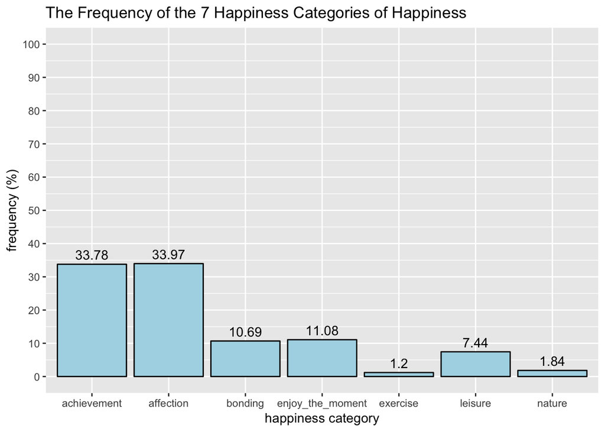

From this graph, it looks like people’s happiness concentrates significantly around themes of achievement and affection. Enjoying the moment and bonding come 3rd and 4th in rank, respectively. Then, Leisure, nature and exercise come 5th, 6th and 7th in rank. Below are the most frequently used words to describe lived happy moments. The themes surrounding these words are friendship (friend), family (example: daughter, mom), relationships (wife), celebrations (birthday), and career (job).

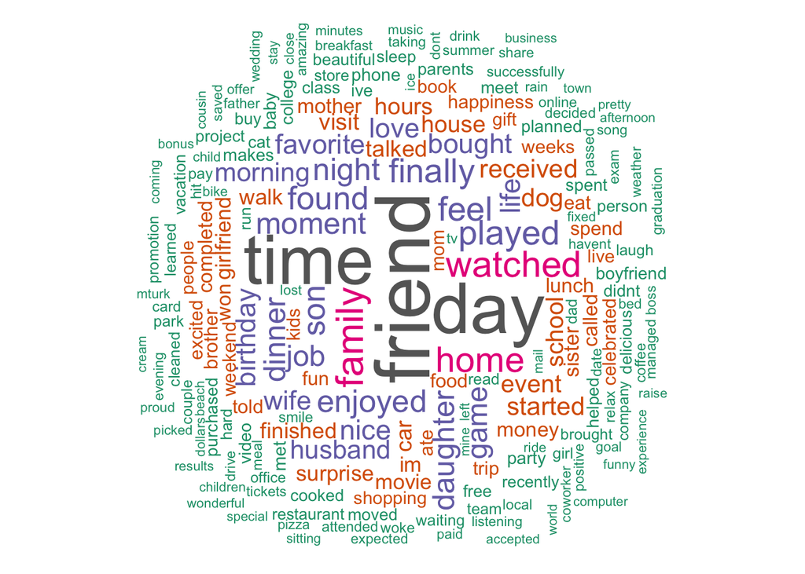

As shown by their extreme close frequency values in the previous graph, this mix between achieving and affection suggests that we look closer at other information that we have, such as age, gender and relationship status. These variables could tell us different stories about the distribution of these happy moments. Accordingly, I will look further into studying genders, young and old people, marital situations, and parenthood.

## 1. Age:

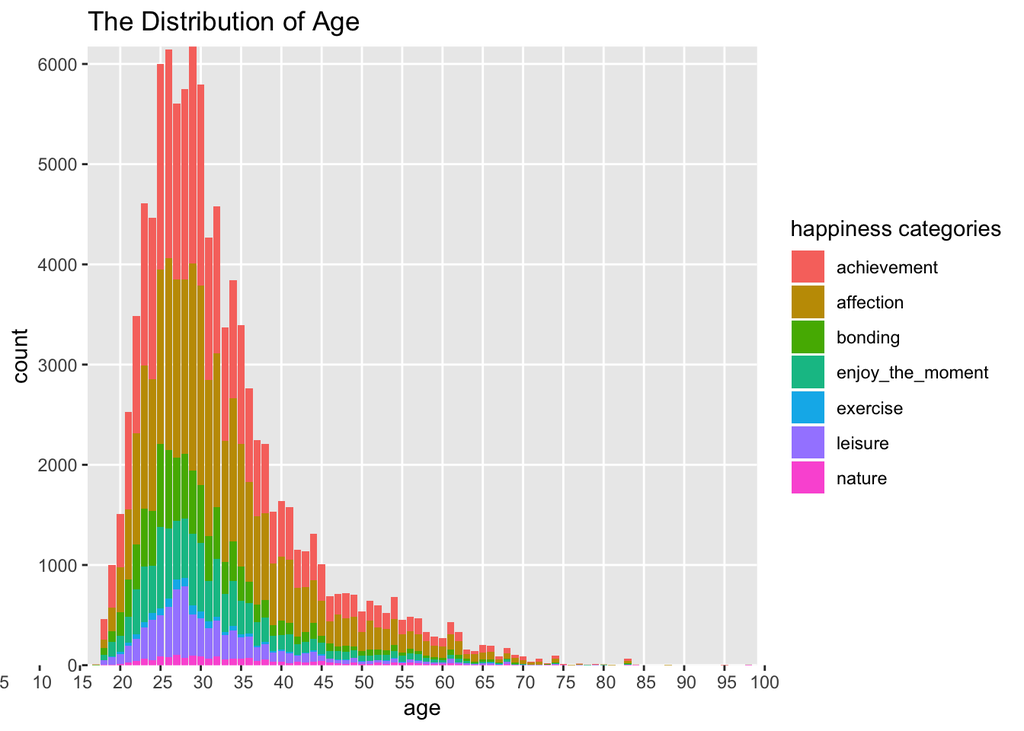

From this graph, we can tell that the age of the majority of people is between the early 20s and early 40s. We can also see that nature and leisure are not big sources of happy moments as much as achievement, affection or bonding are. With such a distribution, and as part of this study, I decided to define the age categories as the following:

1. Younger than 24 years old: teens-early 20s
2. 25-40 years old: young adults
3. 41-65 years old: adults
4. Older than 65 years od: seniors

So let’s see how much of importance does each of the happiness categories have in the lives of our aformentioned age groups:

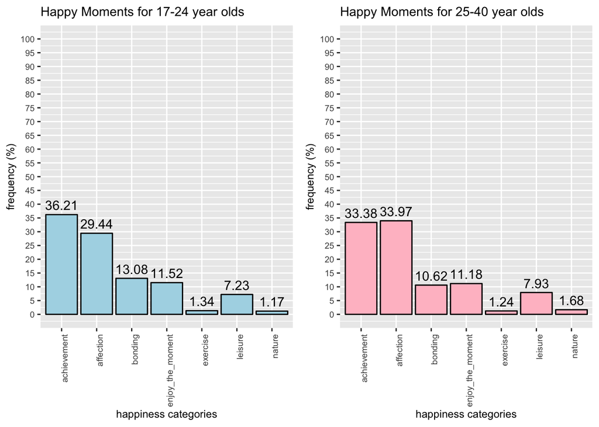

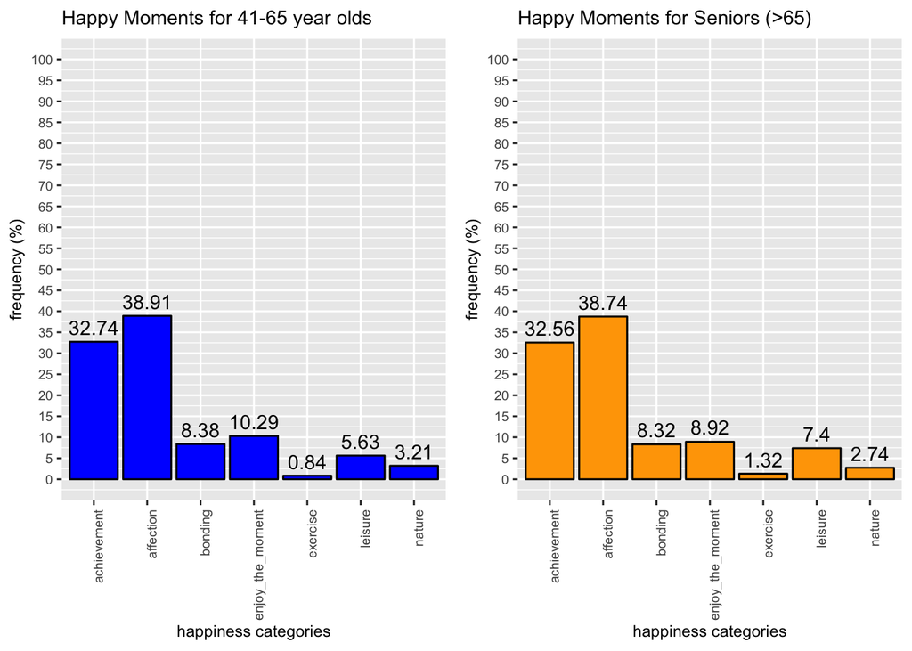

Here, we notice a pattern: as people get older, their happiness gets less impacted by accomplishments and short-lived moments (enjoying the moment category). Instead, their happiness gets more influenced by affection moments. Young people seem to find their joy in achievements rather than affection. As for bonding, we see a shift: for instance, for teens and early 20 year olds, bonding represents a significant part of their happiness (13.08%) compared with that for seniors where it represents 8.32%–slightly less than living the moment. In fact, such trends sound intuitive: at a certain time and period of life, older people would have become more settled in their lives with their careers and relationships, thus mostly caring for their emotional needs. On the other hand, the young adults are more focused on their academics, career and living conditions. The following graphs showcase the discrepancy and similarity in the most frequent words used by adults between 24 and 40 years and seniors.

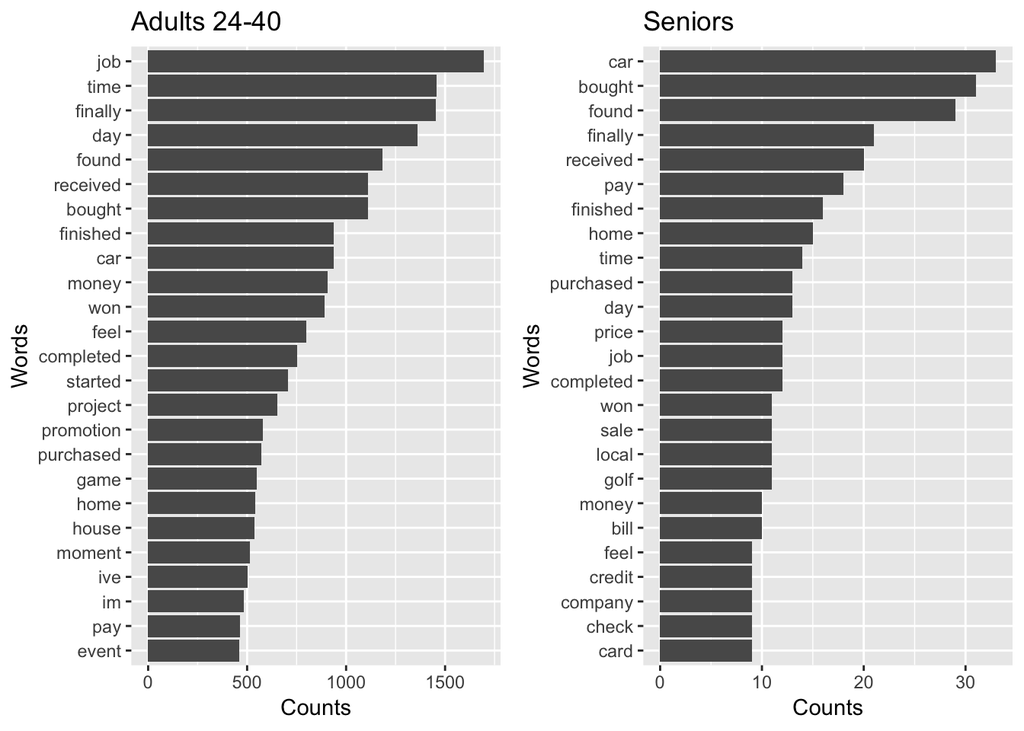

We can see that the happiness stemming from accomplishment for adults between 24 and 40 years old is related to job, promotion, money and getting tasks done. Seniors have almost the same but also different frequent words; evidently the concerns of the two age groups is different given they’re at different life stages. Yet, a common noticeable point is materialism as both age groups tend to mention owning things through using words like: received, purchased, bough, price, money. Now, let’s look at genders and see if one has a different say from the other as regards moments of happiness.

## 2. Gender:

In this regard, I will study the two prominent genders in the data: female and male (I will use women and men as labels)

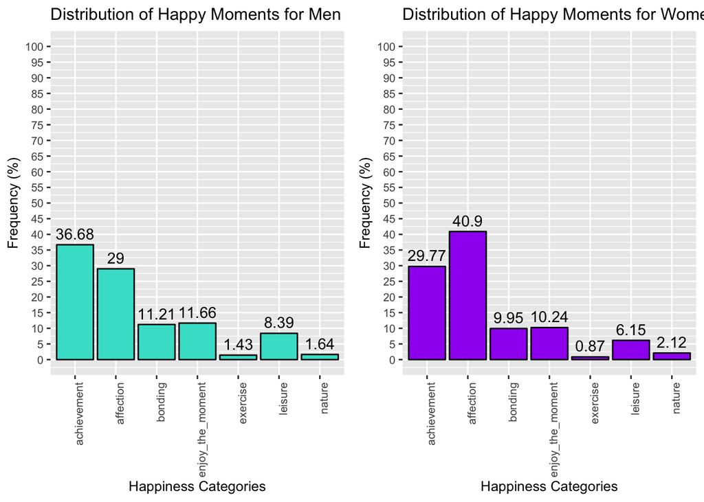

Interestingly, moments of affection seem to significantly highlight women’s happiness (~41%) more than moments of achievement do. Men’s happiness seems to concentrate around achievement (36.68%), then affection (29%) then enjoying the moment and bonding (11.66% and 11.21% respectively). So what words did they frequently use to describe this?

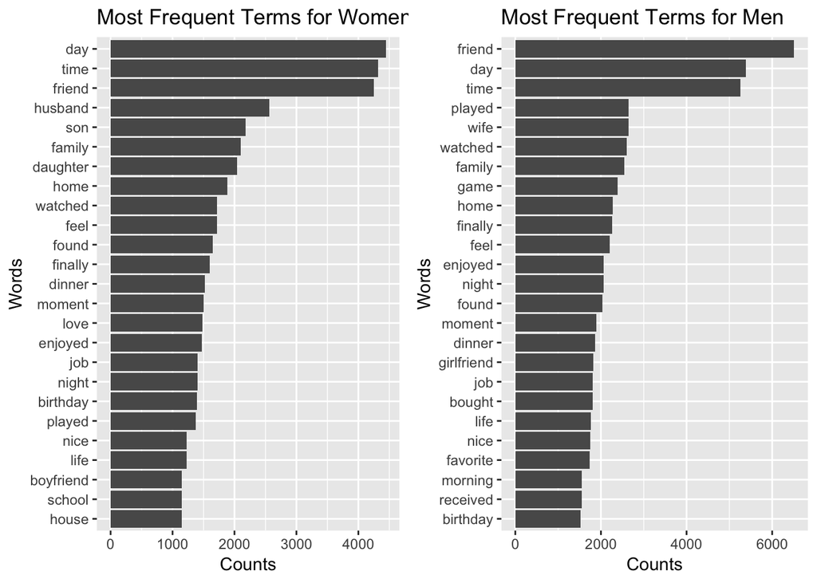

The previously demonstrated disparities suggest that men and women have their own relative perspective of happiness. Men are driven by accomplishments more than affection, as opposed to women. Nevertheless, is this true for all women and men? Later in the analysis, we will get to discover more, but for now let’s explore the marital status of the individuals in our data.

## 3. Marital Status:

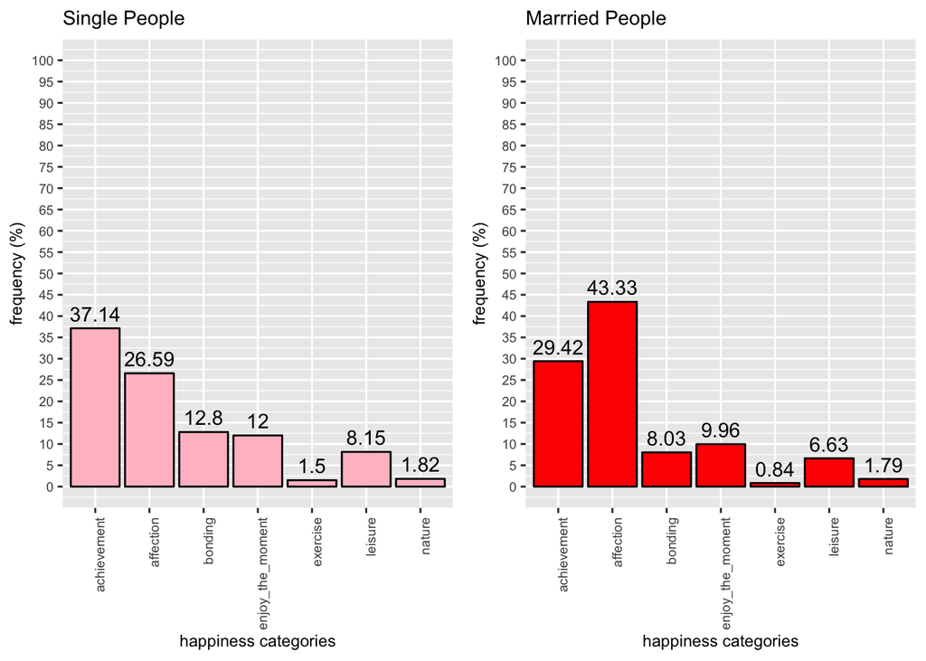

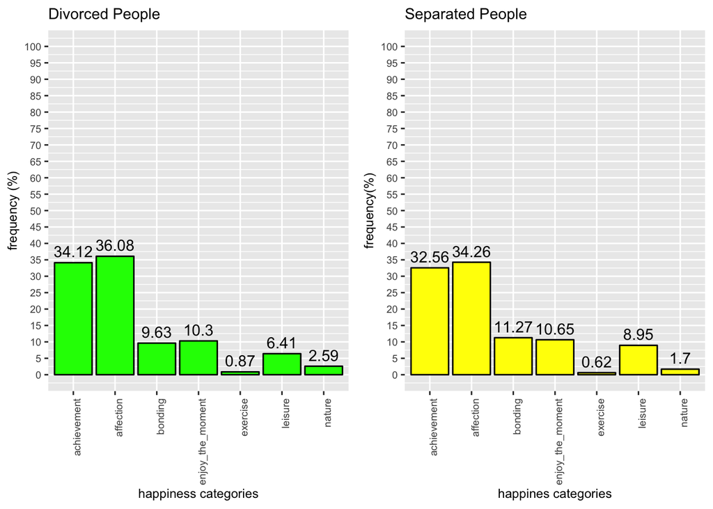

Overall, affection and achievement followed by bonding and living the moment seem to define people’s happiness. Yet, again, can we generalize this and make it true to everyone? To answer this, I will now consider a combination of factors: age, gender, marital status, and parenthood.

## 4. Personas:

Let’s consider two different profiles for both women and men: the profiles are of same age but one is single with no children and the other is a married mother. I would like to see what dominantly defines affection for each of these profiles to see if marital status and having children has any impact in altering one’s perspective of happiness.

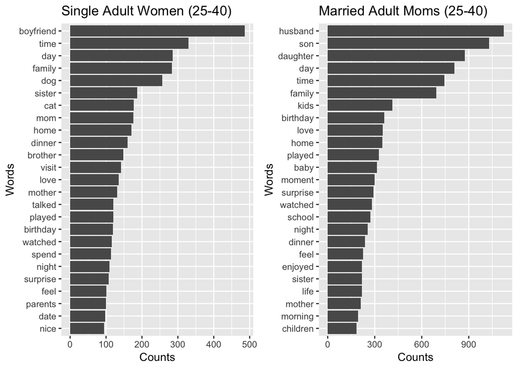

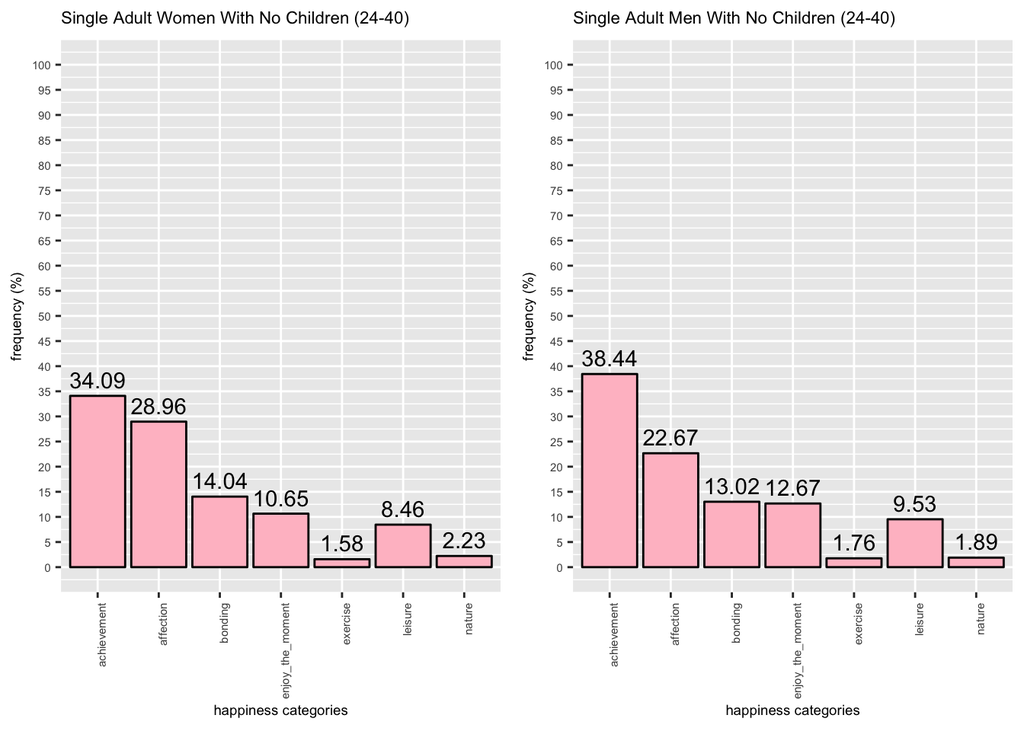

# Summary

So in which category are you? What makes YOU happy?

# References

1. https://github.com/rit-public/HappyDB